# Desafio - S09

Bruno Lima Queiroz Santos T22.3

DUE 22/11/2019

====================================

Copie a coluna ASK (coluna Y) do excel.

```r
library("openxlsx")
#my_data <- read.table(file = "clipboard",
                      #sep = "\t", header=TRUE)
my_data <- openxlsx::read.xlsx("C:/Rprograms/S09/consulta6-2018.xlsx")
x<-my_data[,"ASK"] #extraindo um vetor do dataset !
x<-x[!is.na( x )] # extraindo caracteres vazios
x<-x[x!=0] # extraindo zeros
summary(x) # descrição de características da variável
```

```
##      Min.   1st Qu.    Median      Mean   3rd Qu.      Max.
##       504    495690   2948190  11255924  10657032 317116566
```

Entao, é possível ver que:

$$1- Mean = 11255924$$

$$3- Median = 2948190$$

```r
freq=table(x) # criando uma tabela de ocorrências

names(freq)[freq==max(freq)] # descrevendo o nome da moda
```

```
## [1] "597552"
```

$$2- Moda = 597552$$

```r
var(x) # calculando a variância da variável
```

```
## [1] 5.15613e+14
```

$$4-Variância=5,16 \cdot 10^{14}$$

```r
sd(x) # calculando o desvio padrão da variável
```

```
## [1] 22707112
```

$$5- Desvio \enspace padrão = 22707112$$

```r
mad(x) #  calculando the median absolute deviation
```

```
## [1] 4175710
```

$$6- Desvio \enspace mediano \enspace absoluto = 4175710$$

### 7- Construindo um boxplot para os dados originais com outliers:

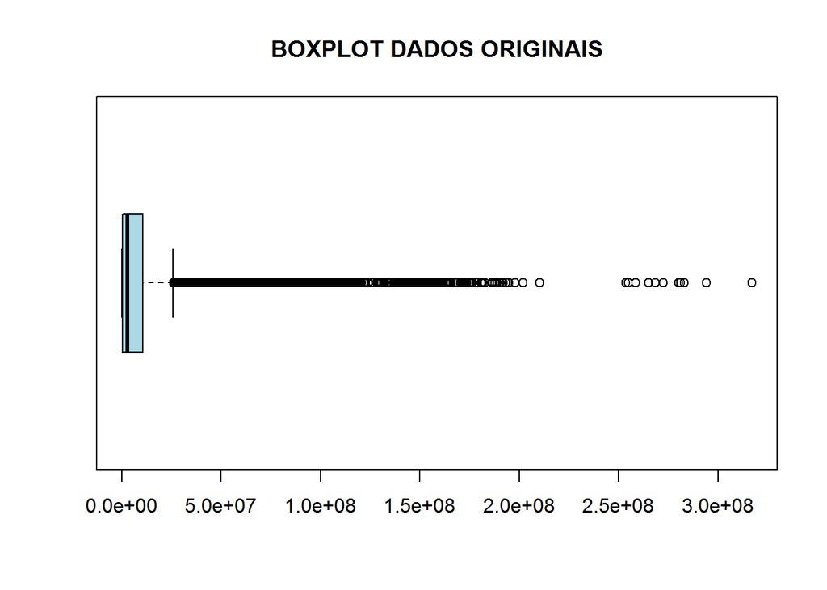

```r
boxplot(x,horizontal=TRUE, col="lightblue",outline=TRUE,main="BOXPLOT DADOS ORIGINAIS") #bloxplot horizontal
```

### Construindo um boxplot para os dados originais sem outliers:

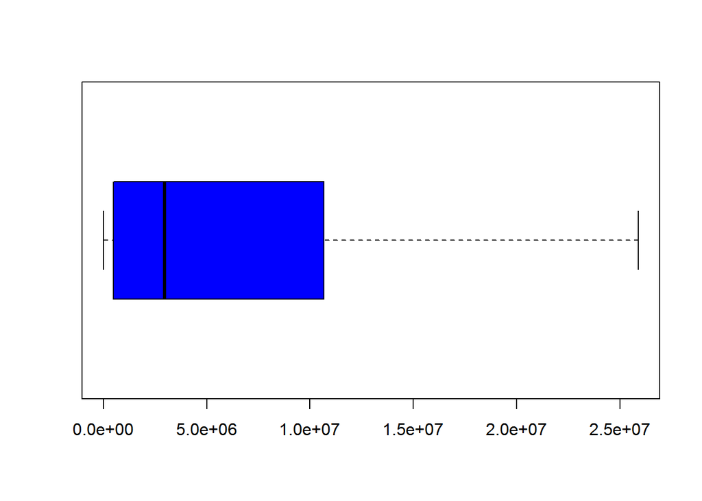

```r
boxplot(x,horizontal=TRUE, col="blue",outline=FALSE) #bloxplot horizontal
```

### Padronização dos dados

```r
Z=(x-mean(x))/(sd(x))
```

#### Testanto a amostra padronizada:

```r
print(mean(Z)) #Printando a média de Z
```

```
## [1] 5.947957e-17
```

```r
# A média deve ser nula

print(sd(Z)) # Exibindo o desvio padrão de Z
```

```
## [1] 1
```

```r
# O desvio padrão deve ser a unidade

print(var(Z)) #Exibindo a variância de Z
```

```
## [1] 1
```

```r
# A variância deve ser a unidade
```

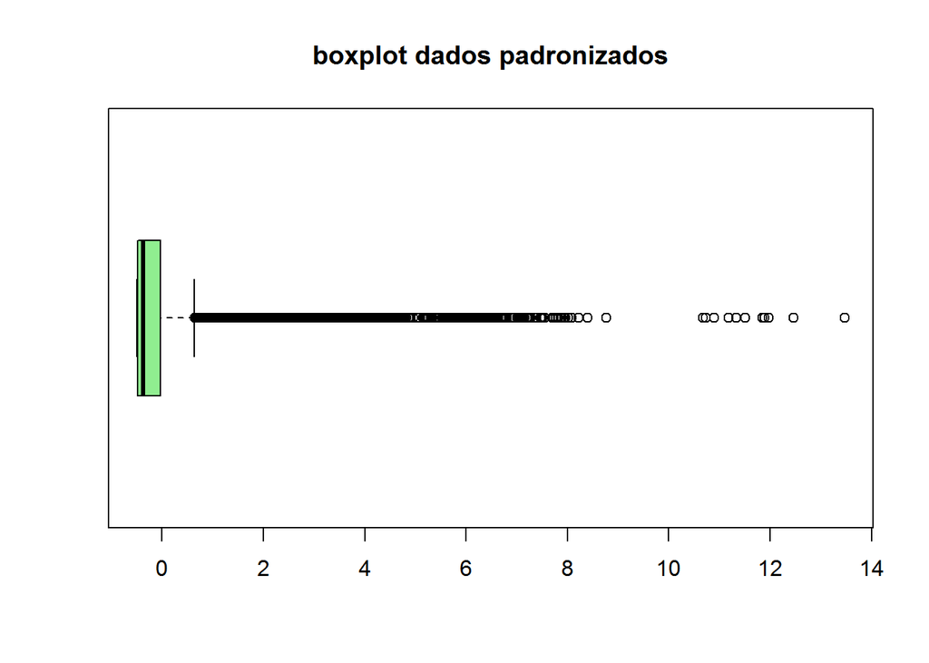

```r
boxplot(Z,horizontal=TRUE, col="lightgreen",outline=TRUE,main="boxplot dados padronizados") #bloxplot horizontal
```

### 8- Apresentando um histograma para os dados originais e os padronizados:

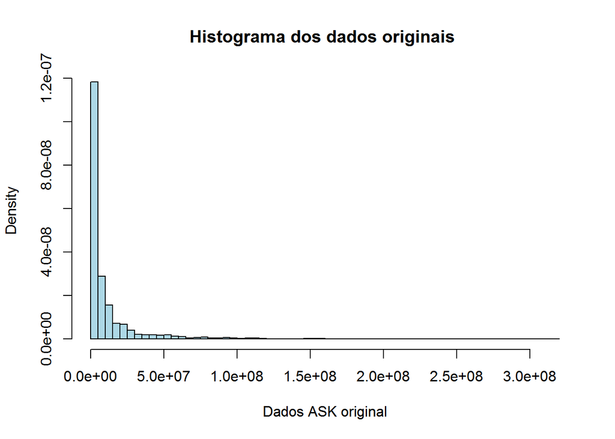

```r
hist(
    x,breaks=100,
    xlab= "Dados ASK original",
    freq = FALSE,col="lightblue",
    main = "Histograma dos dados originais "
    )
```

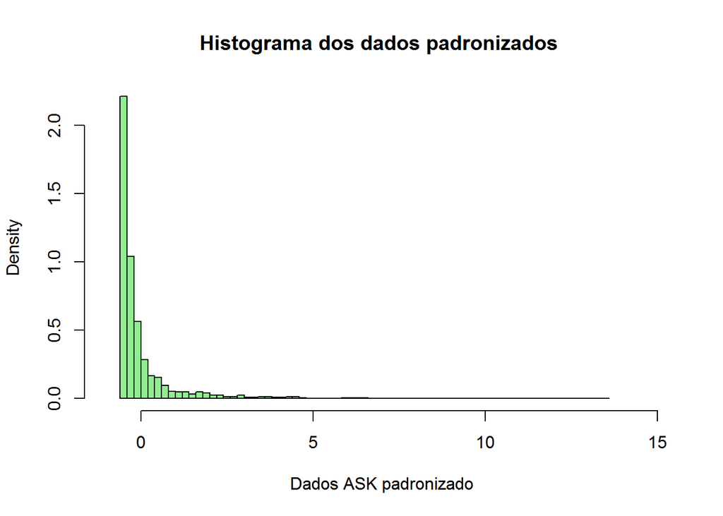

```r
hist(
    Z,
    xlab= "Dados ASK padronizado",
    freq = FALSE,col="lightgreen",
    main = "Histograma dos dados padronizados ",

    #breaks=seq(-2,16,2),

    breaks=50,
    xlim=c(-1,15),
    border="black",
    )
```

### 9 e 10- QQPlot e QQLine sobre os dados:

```r
library("car")
```

```r
qqPlot(x)
```

```
## [1] 25841 25856
```

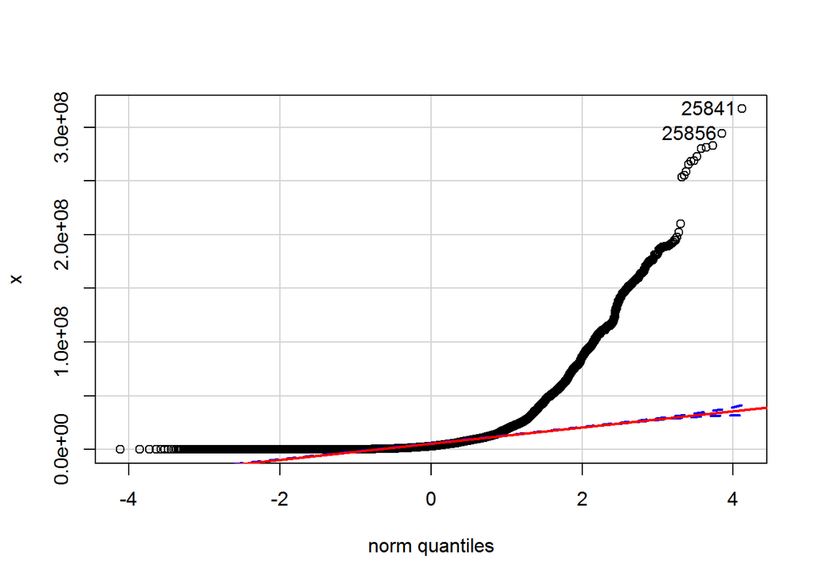

```r
qqline(x,col="red",lwd=2)
```

### 11- Assimetria amostral não viesada

Utilizando:

$s_{3}= \frac{n} { (n-1)(n-2) }\cdot \sum^{n}_{i=1} ( \frac{X_{i}-\overline{X}}{s} )^{3}$

```r
n<-length(x)
s_3<-(n/((n-1)*(n-2)))*sum(((x-mean(x))/sd(x))^3)
#s_3<-sum(Z^3)/n
```

obtém-se a Assimetria amostral não viesada:

```r
print(s_3)
```

```
## [1] 4.219025
```

Concebendo resultados pelo pacote e1071

```r
library(e1071)
skewness(x,1)
```

```
## [1] 4.218539
```

```r
skewness(x,2)
```

```
## [1] 4.218539
```

```r
skewness(x,3)
```

```
## [1] 4.218539
```

Concebendo resultados pelo pacote moments

```r
library("moments")
skewness(x)
```

```
## [1] 4.218782
```

Percebe-se que os resultados gerados são consistentes e compatíveis entre si.

A assimetria amostral dos dados indica o comportamento dos desvios das observações em relação a sua média. Ou seja, a assimetria amostral significa a diferença entre os desvios das observações à direita e à esquerda da média das observações. Portanto, o Coeficiente de Assimetria Amostral dos dados é positivo, logo a distribuição é assimétrica positiva, denotando a existência de pontos positivos (outliers positivos) muito maiores do que os negativos.

### 12- Curtose amostral não viesada

Calculando-se a curtose amostral:

$$s_{4}=
\frac{
n(n+1)
}{
(n-1)(n-2)(n-3)
}\sum^{n}_{i=1}
\Bigg(
\frac{
X_{i}-\overline{X}
}{
s
}
\Bigg)^{4}-3\frac{(n-1)^{2}}{(n-2)(n-3)}$$

```r
s_4<-((n*(n+1))/((n-1)*(n-2)*(n-3)))*sum(((x-mean(x))/sd(x))^4)-(3*((n-1)^2))/((n-2)*(n-3))
```

```r
print(s_4)
```

```
## [1] 24.38912
```

Concebendo resultados pela library e1071

```r
library("e1071")
kurtosis(x,3)
```

[output not shown]

```r
kurtosis(x,2)
```

[output not shown]

```r
kurtosis(x,1)
```

[output not shown]

Concebendo resultados pela library moments

```r
library("moments")
kurtosis(x)
```

```
## [1] 27.3842
```

Curtose é uma medida que avalia o achatamento da curva da função de distribuição.Assim, obteve-se uma função de distribuição leptocúrtica, cujo coeficiente de curtose é maior que zero, possuindo uma curva mais afunilada, com um pico mais agudo, acentuado do que o de uma distribuição normal.

### 13-Testes de Normalidade

#### i) Teste de Kolmogorov-Smirnov [ks.test]

Hipótese nula $H_{0}$: os dados seguem uma distribuição normal. Hipótese $H_{1}$: os dados não seguem uma distribuiçao normal.

Este teste examina a maior diferença absoluta entre a função distribuição acumulada assumida para os dados, isto é, entre a Normal e a empírica. O seu critério é a comparação a um valor crítico, para um dado nível de significância.

```r
y<-rnorm(length(x))
ks.test(x,y)
```

```
##
##  Two-sample Kolmogorov-Smirnov test
##
## data:  x and y
## D = 1, p-value < 2.2e-16
## alternative hypothesis: two-sided
```

De acordo com o teste de normalidade, p-valor foi menor que $0.05$, isto é, menor que $5.0\%$, o que significa que o teste rejeita a hipótese de normalidade, ou seja, a hipótese nula é rejeitada.

#### ii) Teste de Shapiro-Wilk [shapiro.test]

```r
shapiro.test(x[1:5000])
```

```
##
##  Shapiro-Wilk normality test
##
## data:  x[1:5000]
## W = 0.44128, p-value < 2.2e-16
```

Este teste é irrealizável pela função do R para um conjunto de dados muito grande, como é este caso. Porém, pode-se aplicar o teste a um subconjunto do conjunto de dados.

Após aplicar esse teste, obteve-se a rejeição da hipótese de normalidade, ou seja, o teste rejeitou a hipótese nula, porque o p-valor é menor que $5.0\%$.

#### iii) Teste de Anderson-Darlin [ad.test]

```r
library(nortest)
ad.test(x)
```

```
##
##  Anderson-Darling normality test
##
## data:  x
## A = 4033.3, p-value < 2.2e-16
```

Então, a hipótese nula é rejeitada pelo teste, porque o p-valor é menor que $5.0\%$.Portanto, o teste rejeita a hipótese de normalidade.

#### iv) Lilliefors [lillie.test]

```r
lillie.test(x)
```

```
##
##  Lilliefors (Kolmogorov-Smirnov) normality test
##
## data:  x
## D = 0.31006, p-value < 2.2e-16
```

Então, a hipótese nula é rejeitada pelo teste, porque o p-valor é menor que $5.0\%$.Portanto, o teste rejeita a hipótese de normalidade.

#### Comparativo entre os testes de Normalidade.

Como comparação sucinta, pode-se observar a propriedade destaque de cada teste.

O KS test requer que a distribuição nula, isto é, a distribuição de referência, seja completamente especificada com parâmetros conhecidos.

O lillie test é uma modificação do KS test. Ele é adequado quando os parâmetros desconhecidos da distribuição nula devem ser estimados de uma amostra de dados.

O AD test é uma modificação do KS test. Ele atribui mais peso às caudas do que o KS test.

O Shapiro test é um teste poderoso e adequado mesmo para um pequeno número de observações. Porém, ao contrário dos demais testes, Shapiro test é aplicável apenas para checar distribuições normais.